# Automobile Data Analysis

## (By Alonge Daniel)

### About Data

This data set consists of three types of entities: (a) the specification of an auto in terms of various characteristics, (b) its assigned insurance risk rating, (c) its normalized losses in use as compared to other cars. The second rating corresponds to the degree to which the auto is more risky than its price indicates. Cars are initially assigned a risk factor symbol associated with its price. Then, if it is more risky (or less), this symbol is adjusted by moving it up (or down) the scale. Actuarians call this process "symboling". A value of +3 indicates that the auto is risky, -3 that it is probably pretty safe.

The third factor is the relative average loss payment per insured vehicle year. This value is normalized for all autos within a particular size classification (two-door small, station wagons, sports/speciality, etc...), and represents the average loss per car per year.

Note: Several of the attributes in the database could be used as a "class" attribute.

Attribute Information:

Attribute: Attribute Range

1. symboling: -3, -2, -1, 0, 1, 2, 3.
2. normalized-losses: continuous from 65 to 256.
3. make: alfa-romero, audi, bmw, chevrolet, dodge, honda,isuzu, jaguar, mazda, mercedes-benz, mercury,mitsubishi, nissan, peugot, plymouth, porsche,renault, saab, subaru, toyota, volkswagen, volvo
4. fuel-type: diesel, gas.
5. aspiration: std, turbo.
6. num-of-doors: four, two.
7. body-style: hardtop, wagon, sedan, hatchback, convertible.
8. drive-wheels: 4wd, fwd, rwd.
9. engine-location: front, rear.
10. wheel-base: continuous from 86.6 120.9.
11. length: continuous from 141.1 to 208.1.
12. width: continuous from 60.3 to 72.3.
13. height: continuous from 47.8 to 59.8.
14. curb-weight: continuous from 1488 to 4066.
15. engine-type: dohc, dohcv, l, ohc, ohcf, ohcv, rotor.
16. num-of-cylinders: eight, five, four, six, three, twelve, two.
17. engine-size: continuous from 61 to 326.
18. fuel-system: 1bbl, 2bbl, 4bbl, idi, mfi, mpfi, spdi, spfi.
19. bore: continuous from 2.54 to 3.94.
20. stroke: continuous from 2.07 to 4.17.
21. compression-ratio: continuous from 7 to 23.
22. horsepower: continuous from 48 to 288.
23. peak-rpm: continuous from 4150 to 6600.
24. city-mpg: continuous from 13 to 49.
25. highway-mpg: continuous from 16 to 54.
26. price: continuous from 5118 to 45400.
- **NOTE:** for the dataset use for this project only 20 of the features listed above were uses

Source: [UCI Machine Learning Repository](https://archive.ics.uci.edu/ml/datasets/Automobile)

### Accessing Data

|  | make | fuel_type | num_of_doors | body_style | drive_wheels | engine_location | wheel_base | length | width | height | curb_weight | engine_type | num_of_cylinders | engine_size | fuel_system | compression_ratio | horsepower | city_mpg | highway_mpg | price |
| --- | --- | --- | --- | --- | --- | --- | --- | --- | --- | --- | --- | --- | --- | --- | --- | --- | --- | --- | --- | --- |
| 0 | alfa-romero | gas | two | convertible | rwd | front | 88.6 | 168.8 | 64.1 | 48.8 | 2548 | dohc | four | 130 | mpfi | 9.0 | 111 | 21 | 27 | 13495 |
| 1 | alfa-romero | gas | two | convertible | rwd | front | 88.6 | 168.8 | 64.1 | 48.8 | 2548 | dohc | four | 130 | mpfi | 9.0 | 111 | 21 | 27 | 16500 |
| 2 | alfa-romero | gas | two | hatchback | rwd | front | 94.5 | 171.2 | 65.5 | 52.4 | 2823 | ohcv | six | 152 | mpfi | 9.0 | 154 | 19 | 26 | 16500 |
| 3 | audi | gas | four | sedan | fwd | front | 99.8 | 176.6 | 66.2 | 54.3 | 2337 | ohc | four | 109 | mpfi | 70.0 | 102 | 24 | 30 | 13950 |
| 4 | audi | gas | four | sedan | 4wd | front | 99.4 | 176.6 | 66.4 | 54.3 | 2824 | ohc | five | 136 | mpfi | 8.0 | 115 | 18 | 22 | 17450 |

### Investigate Data

#### Observations

- Amidst the 20 featurs only num_of_doors feature has 2 null column
- Its also observe that the minimum value in the price column is 0 which dosen't realy make sence for a car to be sold at 0 dollars
- In the number of cylinders there's a single value in it that's rpresent as tow instead of two
- Also in the drive wheel columns some of the columns some cars that were 4wd were represented with an extra space which affect the consistency of the data

### Data Cleaning

- fix the null columns in the num_of_doors feature with the mode Value

```
The total number of nan values is :  0
```

- Change value of the prices with zero to the mean value of the price column
- In the number of cylinders there's a single value in it that's represent as tow instead of two

```
array(['four', 'six', 'five', 'three', 'twelve', 'two', 'eight'],
      dtype=object)
```

- Also in the drive wheel columns some of the columns some cars that were 4wd were represented with an extra space which affect the consistency of the data

```
['rwd' 'fwd' '4wd ' '4wd']
['rwd' 'fwd' '4wd']
```

##### Data Analysis

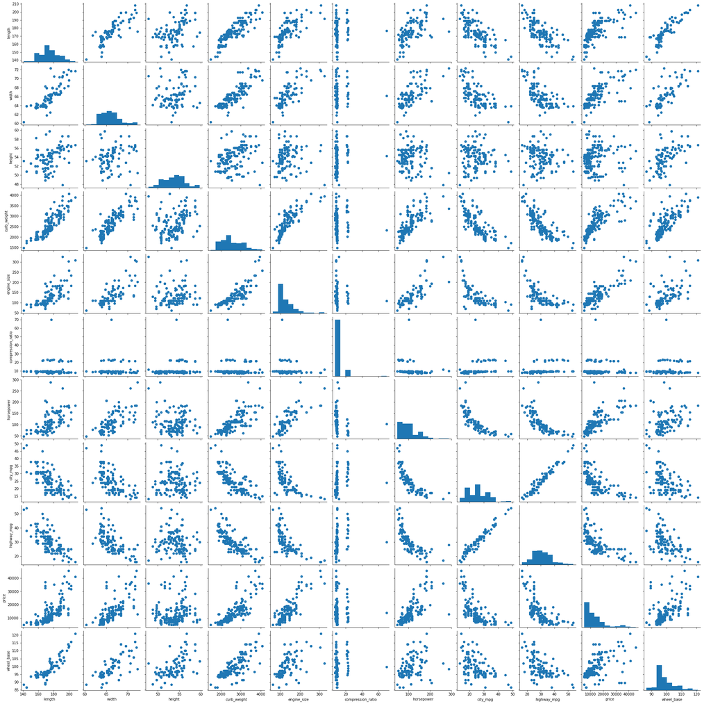

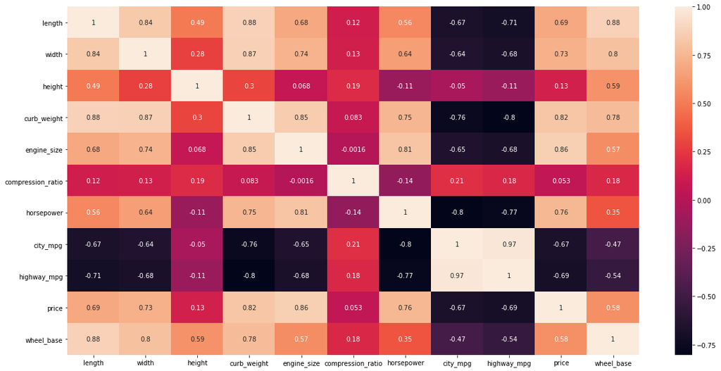

#### Insight

- There's a lot of almost perfect correlation that exist between the numerical datas but the engine_size and the curb_weight are the most correlated feature with Price

### Categorical Feature Counts

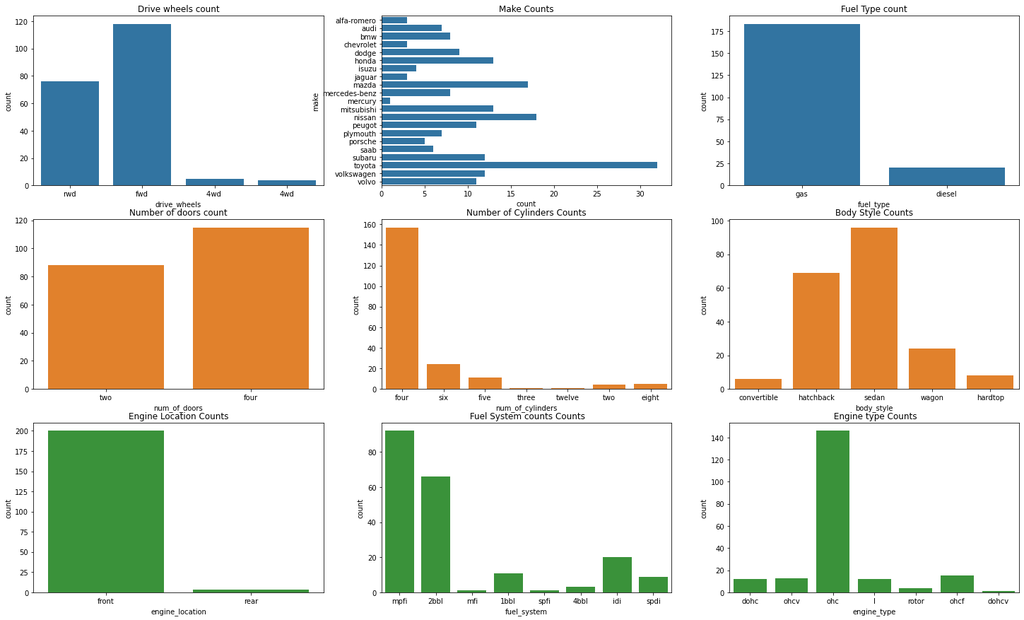

#### Insights

Most of the cars in the datasets has the following ?

- Their engine in front
- four doors
- four cylinders
- ohc enginetype e.t.c

#### Categorical features in relation to price

- Price vs engine_size vs categorical variables

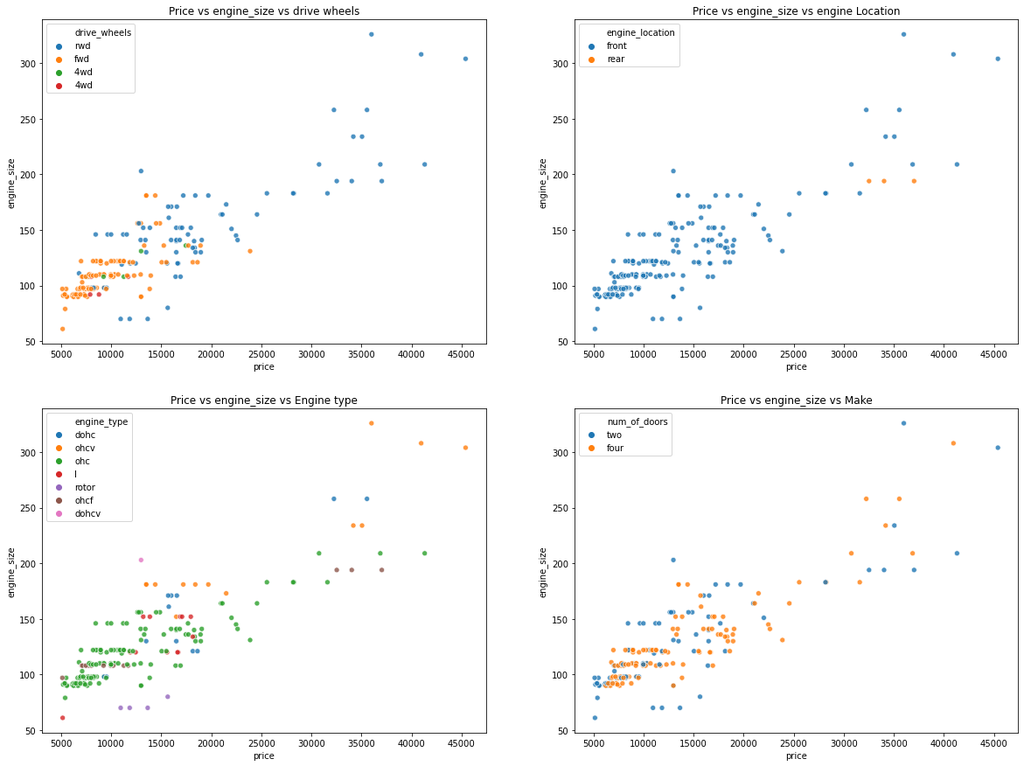

#### Insights

- Base on the above plots the right wheel drive cars are the most expensive cars even more expensive than the 4 wheel drive although the amount of 4wd cars in the datase is not enough to jump into conclusion for a general population
- There's no correlation between the number of doors have and the price
- the few cars with rear engine location are also expensive

### Hypothesis

- Null Hypothesis: There's no relation between the number of doors a car has and the body style
- ALternate Hypothesis: There's a relation between the numbers of doors and the body style

```
............... Contigency Table .............

body_style    convertible  hardtop  hatchback  sedan  wagon
num_of_doors
four                    0        0         10     81     24
two                     6        8         59     15      0
p_value is = 2.7809810889693893e-24
......................................
Null hypothesis Rejected
There's a significant relationshp between the number of doors and the body style
```

### Converting categorical features to numerical features

- Using label encoder

|  | length | width | height | curb_weight | engine_size | compression_ratio | horsepower | city_mpg | highway_mpg | price | wheel_base | make | fuel_type | num_of_doors | body_style | drive_wheels | engine_location | engine_type | num_of_cylinders | fuel_system |
| --- | --- | --- | --- | --- | --- | --- | --- | --- | --- | --- | --- | --- | --- | --- | --- | --- | --- | --- | --- | --- |
| 0 | 168.8 | 64.1 | 48.8 | 2548 | 130 | 9.0 | 111 | 21 | 27 | 13495.0 | 88.6 | 0 | 1 | 1 | 0 | 3 | 0 | 0 | 2 | 5 |
| 1 | 168.8 | 64.1 | 48.8 | 2548 | 130 | 9.0 | 111 | 21 | 27 | 16500.0 | 88.6 | 0 | 1 | 1 | 0 | 3 | 0 | 0 | 2 | 5 |
| 2 | 171.2 | 65.5 | 52.4 | 2823 | 152 | 9.0 | 154 | 19 | 26 | 16500.0 | 94.5 | 0 | 1 | 1 | 2 | 3 | 0 | 5 | 3 | 5 |
| 3 | 176.6 | 66.2 | 54.3 | 2337 | 109 | 70.0 | 102 | 24 | 30 | 13950.0 | 99.8 | 1 | 1 | 0 | 3 | 2 | 0 | 3 | 2 | 5 |
| 4 | 176.6 | 66.4 | 54.3 | 2824 | 136 | 8.0 | 115 | 18 | 22 | 17450.0 | 99.4 | 1 | 1 | 0 | 3 | 1 | 0 | 3 | 1 | 5 |

### Feature Selection

- Select the Top 10 features in building our linear regression model for the price preddiction using the Sequential feature selector

```
SequentialFeatureSelector(estimator=LinearRegression(), k_features=(10, 10),
                          scoring='r2')
```

- The top 10 features are 'width', 'height', 'curb_weight', 'engine_size', 'highway_mpg', 'make', 'body_style', 'drive_wheels', 'engine_location', 'engine_type'

### Model Creation

- Create model and validate using R2 Score

```
Linear Regression Modl Params:  {'copy_X': True, 'fit_intercept': True, 'n_jobs': None, 'normalize': 'deprecated', 'positive': False}
R2 Score= 0.6291129561002341
```

### Save Model

```
Model saved as : car_price_predictor.sav
```

### Conclusion

#### Thanks for viewing

**Author: Alonge Daniel Oluwasegun**